# TruncatedNormal package

The `TruncatedNormal` package provides numerical routines to estimate the probability that Gaussian and Student random vectors fall in a hyperrectangle of the form $[\boldsymbol{l}, \boldsymbol{u}]$, namely $\Pr(\boldsymbol{l} \leq \boldsymbol{X} \leq \boldsymbol{u})$ for $\boldsymbol{X} \sim \mathcal{N}(\boldsymbol{\mu}, \boldsymbol{\Sigma})$ or$\boldsymbol{X} \sim \mathcal{T}_{\nu}(\boldsymbol{\mu}, \boldsymbol{\Sigma})$, where $\boldsymbol{\mu}$ is a location vector, $\boldsymbol{\Sigma}$ is a scale matrix and $\nu$ is the degree of freedom of the Student vector.

The minimax exponential tilting method is an alternative to the separation of variables estimator implemented in the package `mvtnorm`; the package `mvPot` also implements the separation of variables method and uses quasi Monte Carlo, but is restricted to integrals of the form $[-\boldsymbol{\infty}_D, \boldsymbol{u}]$.

### Example 1: Simulation of Gaussian variables subject to linear restrictions

Suppose we wish to simulate a bivariate vector $\boldsymbol{X} \sim \mathcal{N}(\boldsymbol{\mu}, \boldsymbol{\Sigma})$ conditional on $X_1-X_2 < -6$. Setting $\mathbf{A} = \left( \begin{smallmatrix} 1 & -1 \\ 0 & 1\end{smallmatrix}\right)$. We can simulate $\boldsymbol{Y} \sim \mathcal{N}(\mathbf{A}\boldsymbol{\mu},\mathbf{A}\boldsymbol{\Sigma}\mathbf{A}^\top)$ conditional on $\boldsymbol{l} \leq \boldsymbol{Y} \leq \boldsymbol{u}$ and then set $\boldsymbol{X} = \mathbf{A}^{-1}\boldsymbol{Y}$.

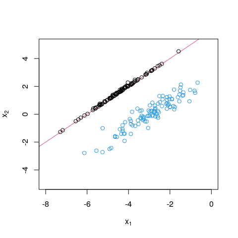

```r
library(TruncatedNormal)
set.seed(1234)
sigma <- matrix(c(1,0.9,0.9,1), ncol = 2)
mu <- c(-3, 0)
u <- c(-6, Inf)
A <- matrix(c(1,-1,0,1), ncol = 2, byrow = TRUE)
# Sample truncated Gaussian variables and back-transforms
Y <- rtmvnorm(n = 1e2, mu = c(A %*% mu), sigma = A %*% sigma %*% t(A), ub = u)
X <- t(solve(A) %*% t(Y))
plot(X, panel.first = abline(a = 6, b = 1, col = 2),
     xlab = expression(x[1]), ylab = expression(x[2]),
     xlim = c(-8,0), ylim = c(-5,5))
# Compare with unconstrained samples
points(rtmvnorm(n=1e2, mu = mu, sigma = sigma), col = 4)
```

### Example 2: Estimating the probability of rare events

We can estimate numerically the probability that $\boldsymbol{X} \geq \boldsymbol{0}_d$ for $\boldsymbol{X} \sim \mathcal{N}(\boldsymbol{0}_d, 0.5\mathbf{I}_d + 0.5\mathbf{1}_d\mathbf{1}_d^\top)$, which is known and equal $(d+1)^{-1}$.

```r
d <- 1000
sigma <- 0.5 * (diag(d) + matrix(1, d, d))
est <- pmvnorm(sigma = sigma, lb = rep(0, d), type = "qmc", B = 1e4)
print(est)
```

```
#> [1] 0.0009987621
#> attr(,"relerr")
#> [1] 0.007122615
#> attr(,"upbnd")
#> [1] 0.002963262
```

```r
#Compare est with exact value by computing relative error
abs(est - 1/(d+1))*(d+1)
```

```
#> [1] 0.0002391284
#> attr(,"relerr")
#> [1] 0.007122615
#> attr(,"upbnd")
#> [1] 0.002963262
```

### Example 3: High-dimensional truncated Student with positive correlation

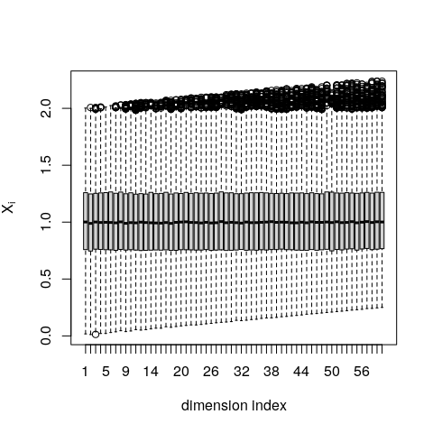

```r
d <- 60
sigma <- 0.1 * diag(d) + 0.9 * matrix(1, d, d)
l <- (1:d)/(4*d); u <- l + 2
X <- rtmvt(n = 1e4, sigma = sigma, lb = l, ub = u, df = 3)
boxplot(t(X) ~ as.factor(1:d), xlab = "dimension index",
        ylab = expression(X["i"]))
```

### Example 4: Normal quantile function with tail-precision

The package includes two normal quantile functions that can be used to simulate truncated Gaussian variables with high precision using the inverse transform method (which is useful for quasi Monte Carlo integration) or a fast alternative.

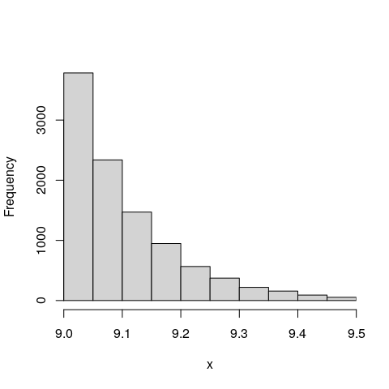

```r
l <- 9; u <- 9.5
hist(rtnorm(n = 1e4, lb = l, ub = u),
     xlim = c(9,9.5), xaxs = "i", main = "", xlab = "x")
```

```r
# Now compare speed of the two methods
timing <- matrix(0, ncol = 2, nrow = 20)
for(i in 1:20){
  timing[i,] <- c(
    system.time(rtnorm(n = 1e5, lb = l, ub = u, method = "fast"))[3],
    system.time(rtnorm(n = 1e5, lb = l, ub = u, method = "invtransfo"))[3]
  )
}
colMeans(timing)
```

```
#> [1] 0.0111 0.0212
```

### Example 5: Probit regression

The example uses the *Lupus nephritis* dataset from

> D. A. van Dyk and X.-L. Meng (2001). *The art of data augmentation (with discussion)*. Journal of Computational and Graphical Statistics, **10**(1), pp. 1-50.

If $\boldsymbol{\beta}\sim \mathcal{N}(\mathbf{0},\sigma^2 \mathbf{I}_d)$ for known $\sigma^2$, we first simulate
$$\mathbf{Z}\sim N(\mathbf{0},\boldsymbol{\Sigma}),\qquad \boldsymbol{\Sigma}=\mathbf{I}_d+\sigma^2 \mathbf{X X}^\top,$$
conditional on $\mathbf{Z}\geq \mathbf{0}$ and next simulate the posterior regression coefficients of the probit regression, $\boldsymbol{\beta}$, viz.
$$\boldsymbol{\beta}|\mathbf{Z}\sim \mathcal{N}(\mathbf{C X}^\top \mathbf{Z},\mathbf{C}),\qquad \mathbf{C}^{-1}=\mathbf{I}_d/\sigma^2+ \mathbf{X}^\top\mathbf{X}.$$

We can perform similar inference with the *Lupus nephritis* dataset

```r
# Exact Bayesian Posterior Simulation Example.

data("lupus"); # load lupus data
Y <- lupus[,1]; # response data
X <- as.matrix(lupus[,-1])  # construct design matrix
n <- nrow(X)
d <- ncol(X)
X <- diag(2*Y-1) %*% X; # incorporate response into design matrix
nusq <- 10000; # prior scale parameter
C <- solve(diag(d)/nusq + crossprod(X))
sigma <- diag(n) + nusq*tcrossprod(X) # this is covariance of Z given beta
est <- pmvnorm(sigma = sigma, lb = 0)
# estimate acceptance probability of crude Monte Carlo
print(attributes(est)$upbnd/est[1])
```

```
#> [1] 5.483607
```

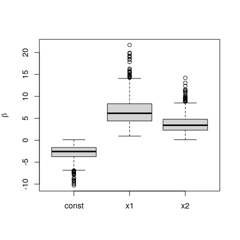

```r
# reciprocal of acceptance probability
Z <- rtmvnorm(sigma = sigma, n = 1e3, lb = rep(0, n))
 # sample exactly from auxiliary distribution
beta <- rtmvnorm(n = nrow(Z), sigma = C) + Z %*% X %*% C
 # simulate beta given Z and plot boxplots of marginals
boxplot(beta, ylab = expression(beta))
```

```r
# plot the boxplots of the marginal distribution of the betas
print(colMeans(beta)) # output the posterior means
```

```
#>     const        x1        x2
#> -2.863832  6.695612  3.800347
```

### Example 6: Tobit regression

We use the women wage dataset from

> T. A. Mroz, 1987. *The Sensitivity of an Empirical Model of Married Women’s Hours of Work to Economic and Statistical Assumptions*, Econometrica, **55**(4), pp. 765-799

If we wish to sample from the Bayesian posterior with improper prior $p(\boldsymbol{\beta}) \propto 1$ and $p(\sigma) \propto \sigma^{-2}$, the posterior is

$$p(\boldsymbol{\beta},\sigma \mid \boldsymbol{y}, \mathbf{X})\propto \sigma^{-2}\exp\left[-\sum_{i:y_i>u_i}\left\{\frac{(y_i-\mathbf{x}_i^\top\beta)^2}{2\sigma^2}+\log(\sigma)\right\}+\sum_{i: y_i=u_i}\log\left\{\Phi\left( \frac{u_i-\mathbf{x}_i^\top\beta}{\sigma}\right)\right\}\right].$$
A change of variable $(\boldsymbol{\beta}, \sigma) \mapsto (\boldsymbol{z}, r)$ shows that simulating from the above posterior is equivalent to simulating from the truncated posterior distribution function
$$p(\mathbf{z}, r\mid \boldsymbol{y}, \mathbf{X})\propto
\exp\left\{-\frac{\mathbf{z}^\top\mathbf{z}}{2}-\frac{r^2}{2}+(\nu-1)\ln
r\right\}\mathrm{I}\{\sqrt{\nu}\, \mathbf{L}\mathbf{z}\geq r \mathbf{ l}\},$$
where $\mathbf{L}$ is a lower triangular matrix and $\mathbf{l}$ is a vector of lower truncation limits. The distribution of $\nu^{1/2} \mathbf{LZ}/R$ is truncated multivariate Student $\mathcal{T}_{\nu}(\mathbf{LL}^\top)$ with lower limit $\mathbf{l}$.

Partition the response vector and the design matrix into $\boldsymbol{y} = [\boldsymbol{y}_u, \boldsymbol{y}_c]$ for the $n_u$ uncensored and $n-n_u$ uncensored observations, with $\mathbf{X}_u$, $\mathbf{X}_c$ the corresponding design matrix and $\mathbf{H}_{\mathbf{X}}$ the projection matrix onto the span of $\mathbf{X}$. Then $s_u = \{\boldsymbol{y}_u^\top(\mathbf{I}_d -\mathrm{H}_{\mathbf{X}_u})\boldsymbol{y}_u\}^{1/2}$ is the estimated standard error of the linear regression with the complete cases, $\nu = n_u-d+1$ are the degrees of freedom, $\widehat{\boldsymbol{\beta}}_u = (\mathbf{X}_u^\top\mathbf{X}_u)^{-1}\mathbf{X}_u^\top\boldsymbol{y}_u$ are the least square coefficients for the uncensored observations and $\widehat{\boldsymbol{y}}_c = \mathbf{X}_c \widehat{\boldsymbol{\beta}}_u$ the fitted values for the remaining observations.

The change of variable gives $\sigma =s_u/R$ and
$$\boldsymbol{\beta} = (\mathbf{X}_u^\top\mathbf{X}_u + \mathbf{X}_c^\top\mathbf{X}_c)^{-1}\left\{\mathbf{X}_u^\top\boldsymbol{y}_u + \mathbf{X}_c^\top(\widehat{\boldsymbol{y}}_c-\sigma\boldsymbol{Z})\right\}, \qquad \boldsymbol{W} = \widehat{\boldsymbol{y}}_c - \sigma\boldsymbol{Z}.$$
The lower truncation is then $\nu^{1/2}\widehat{\boldsymbol{y}}_c/s_u$.

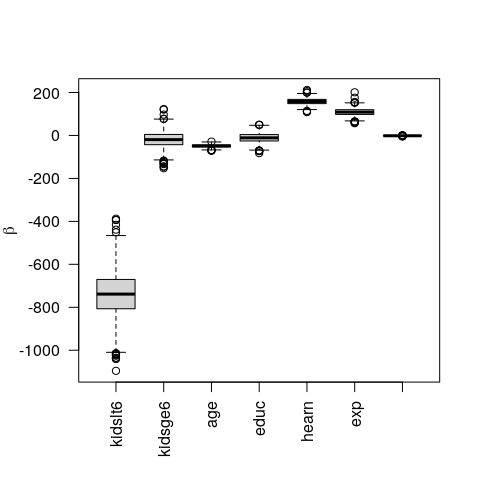

```r
data(mroz, package = "TruncatedNormal")
#Censored observations denote Yc, Yu for uncensored
Y <- mroz[,"whrs"]
X <- cbind(1, as.matrix(mroz[,-1]), I(mroz[,"exp"]^2))
n <- nrow(X); d <- ncol(X)
uncens <- Y > 0
Yu <- Y[uncens]; Yc <- Y[!uncens]
Xu <- X[uncens,]; Xc <- X[!uncens,]
invXtXu <- solve(crossprod(Xu))
sigma <- diag(nrow(Xc)) + Xc %*% invXtXu %*% t(Xc)
s <- sqrt(c(t(Yu) %*% (diag(nrow(Xu))- Xu %*% invXtXu %*% t(Xu)) %*% Yu))
# least squares residual variance estimate
nu <- nrow(Xu) - (d - 1) # degrees of freedom
beta_hat <- invXtXu %*% crossprod(Xu, Yu)
Yc_hat <- c(Xc %*% beta_hat) # fitted values
l <- sqrt(nu) * Yc_hat/s # upper threshold for censoring is zero
# simulate (Z,R) from a truncated Student
B <- 1e3
TR <- tregress(n = B, lb = l, ub = rep(Inf, length(l)), sigma = sigma, df = nu)
R <- TR$R
Z <- t(TR$Z)
# Reverse the mapping (beta,sigma) -> (Z,R)
sig <- s/R # posterior of sigma
C <- solve(crossprod(Xu) + crossprod(Xc))
beta <- matrix(0, nrow = B, ncol = d)
for(i in 1:B){
    W <- Yc_hat - sig[i]*Z[,i] # auxiliary variables
    beta[i,] <- c(C %*% (crossprod(Xu, Yu) + crossprod(Xc, W))) +
                    sig[i]*rtmvnorm(sigma = C, n = 1)
}
colnames(beta) <- colnames(X)
# Boxplots of the marginal posterior distribution
boxplot(beta[,-1], las = 2, ylab = expression(beta))
```

```r
# Plot marginal means and standard deviations
summary(beta)
```

```
#>        V1            kidslt6           kidsge6              age
#>  Min.   :-279.2   Min.   :-1096.0   Min.   :-152.744   Min.   :-71.56
#>  1st Qu.:1118.1   1st Qu.: -806.8   1st Qu.: -42.839   1st Qu.:-53.31
#>  Median :1412.4   Median : -738.6   Median : -19.387   Median :-48.77
#>  Mean   :1414.2   Mean   : -738.6   Mean   : -19.553   Mean   :-48.83
#>  3rd Qu.:1703.1   3rd Qu.: -670.3   3rd Qu.:   4.924   3rd Qu.:-43.95
#>  Max.   :2923.8   Max.   : -387.5   Max.   : 122.872   Max.   :-28.55
#>       educ             hearn            exp               V8
#>  Min.   :-82.322   Min.   :108.8   Min.   : 57.03   Min.   :-4.36975
#>  1st Qu.:-25.529   1st Qu.:148.3   1st Qu.: 98.09   1st Qu.:-1.80218
#>  Median :-10.892   Median :158.2   Median :108.70   Median :-1.47622
#>  Mean   :-10.922   Mean   :158.5   Mean   :109.01   Mean   :-1.48493
#>  3rd Qu.:  4.059   3rd Qu.:168.1   3rd Qu.:119.91   3rd Qu.:-1.12933
#>  Max.   : 49.804   Max.   :211.9   Max.   :201.00   Max.   : 0.06102
```